# Risk Factor Analysis

## Outcome Variable

**Outcome Variable:** wast_rec90d

## Predictor Variables

**Intervention Variable:** mbmi

**Adjustment Set:**

- arm
- W_mage
- meducyrs
- feducyrs
- hhwealth_quart
- W_nchldlt5
- brthmon
- W_parity
- impfloor
- delta_W_mage
- delta_meducyrs
- delta_feducyrs
- delta_hhwealth_quart
- delta_W_nchldlt5
- delta_brthmon
- delta_W_parity
- delta_impfloor

## Stratifying Variables

The analysis was stratified on these variable(s):

- agecat
- studyid
- country

## Data Summary

| agecat | studyid | country | mbmi | wast_rec90d | n_cell | n |
| --- | --- | --- | --- | --- | --- | --- |
| 0-24 months | iLiNS-Zinc | BURKINA FASO | Normal weight | 0 | 624 | 794 |
| 0-24 months | iLiNS-Zinc | BURKINA FASO | Normal weight | 1 | 27 | 794 |
| 0-24 months | iLiNS-Zinc | BURKINA FASO | Underweight | 0 | 135 | 794 |
| 0-24 months | iLiNS-Zinc | BURKINA FASO | Underweight | 1 | 8 | 794 |
| 0-24 months | JiVitA-3 | BANGLADESH | Normal weight | 0 | 2531 | 7538 |
| 0-24 months | JiVitA-3 | BANGLADESH | Normal weight | 1 | 1949 | 7538 |
| 0-24 months | JiVitA-3 | BANGLADESH | Underweight | 0 | 1821 | 7538 |
| 0-24 months | JiVitA-3 | BANGLADESH | Underweight | 1 | 1237 | 7538 |
| 0-24 months | LCNI-5 | MALAWI | Normal weight | 0 | 42 | 78 |
| 0-24 months | LCNI-5 | MALAWI | Normal weight | 1 | 6 | 78 |
| 0-24 months | LCNI-5 | MALAWI | Underweight | 0 | 23 | 78 |
| 0-24 months | LCNI-5 | MALAWI | Underweight | 1 | 7 | 78 |
| 0-24 months | MAL-ED | BANGLADESH | Normal weight | 0 | 30 | 122 |
| 0-24 months | MAL-ED | BANGLADESH | Normal weight | 1 | 64 | 122 |
| 0-24 months | MAL-ED | BANGLADESH | Underweight | 0 | 13 | 122 |
| 0-24 months | MAL-ED | BANGLADESH | Underweight | 1 | 15 | 122 |
| 0-24 months | MAL-ED | BRAZIL | Normal weight | 0 | 6 | 23 |
| 0-24 months | MAL-ED | BRAZIL | Normal weight | 1 | 15 | 23 |
| 0-24 months | MAL-ED | BRAZIL | Underweight | 0 | 0 | 23 |
| 0-24 months | MAL-ED | BRAZIL | Underweight | 1 | 2 | 23 |
| 0-24 months | MAL-ED | INDIA | Normal weight | 0 | 49 | 178 |
| 0-24 months | MAL-ED | INDIA | Normal weight | 1 | 82 | 178 |
| 0-24 months | MAL-ED | INDIA | Underweight | 0 | 21 | 178 |
| 0-24 months | MAL-ED | INDIA | Underweight | 1 | 26 | 178 |
| 0-24 months | MAL-ED | NEPAL | Normal weight | 0 | 20 | 98 |
| 0-24 months | MAL-ED | NEPAL | Normal weight | 1 | 78 | 98 |
| 0-24 months | MAL-ED | NEPAL | Underweight | 0 | 0 | 98 |
| 0-24 months | MAL-ED | NEPAL | Underweight | 1 | 0 | 98 |
| 0-24 months | MAL-ED | PERU | Normal weight | 0 | 5 | 35 |
| 0-24 months | MAL-ED | PERU | Normal weight | 1 | 26 | 35 |

[output cut: 170 more lines]

The following strata were considered:

- agecat: 0-24 months, studyid: iLiNS-Zinc, country: BURKINA FASO
- agecat: 0-24 months, studyid: JiVitA-3, country: BANGLADESH
- agecat: 0-24 months, studyid: LCNI-5, country: MALAWI
- agecat: 0-24 months, studyid: MAL-ED, country: BANGLADESH
- agecat: 0-24 months, studyid: MAL-ED, country: BRAZIL
- agecat: 0-24 months, studyid: MAL-ED, country: INDIA
- agecat: 0-24 months, studyid: MAL-ED, country: NEPAL
- agecat: 0-24 months, studyid: MAL-ED, country: PERU
- agecat: 0-24 months, studyid: MAL-ED, country: SOUTH AFRICA
- agecat: 0-24 months, studyid: MAL-ED, country: TANZANIA, UNITED REPUBLIC OF
- agecat: 0-24 months, studyid: NIH-Birth, country: BANGLADESH
- agecat: 0-24 months, studyid: NIH-Crypto, country: BANGLADESH
- agecat: 0-24 months, studyid: PROBIT, country: BELARUS
- agecat: 0-24 months, studyid: PROVIDE, country: BANGLADESH
- agecat: 0-24 months, studyid: SAS-CompFeed, country: INDIA
- agecat: 0-24 months, studyid: TanzaniaChild2, country: TANZANIA, UNITED REPUBLIC OF
- agecat: 0-24 months, studyid: ZVITAMBO, country: ZIMBABWE
- agecat: 0-6 months, studyid: JiVitA-3, country: BANGLADESH
- agecat: 0-6 months, studyid: LCNI-5, country: MALAWI
- agecat: 0-6 months, studyid: MAL-ED, country: BANGLADESH
- agecat: 0-6 months, studyid: MAL-ED, country: BRAZIL
- agecat: 0-6 months, studyid: MAL-ED, country: INDIA
- agecat: 0-6 months, studyid: MAL-ED, country: NEPAL
- agecat: 0-6 months, studyid: MAL-ED, country: PERU
- agecat: 0-6 months, studyid: MAL-ED, country: SOUTH AFRICA
- agecat: 0-6 months, studyid: MAL-ED, country: TANZANIA, UNITED REPUBLIC OF
- agecat: 0-6 months, studyid: NIH-Birth, country: BANGLADESH
- agecat: 0-6 months, studyid: NIH-Crypto, country: BANGLADESH
- agecat: 0-6 months, studyid: PROBIT, country: BELARUS
- agecat: 0-6 months, studyid: PROVIDE, country: BANGLADESH
- agecat: 0-6 months, studyid: SAS-CompFeed, country: INDIA
- agecat: 0-6 months, studyid: TanzaniaChild2, country: TANZANIA, UNITED REPUBLIC OF
- agecat: 0-6 months, studyid: ZVITAMBO, country: ZIMBABWE
- agecat: 6-24 months, studyid: iLiNS-Zinc, country: BURKINA FASO
- agecat: 6-24 months, studyid: JiVitA-3, country: BANGLADESH
- agecat: 6-24 months, studyid: LCNI-5, country: MALAWI
- agecat: 6-24 months, studyid: MAL-ED, country: BANGLADESH
- agecat: 6-24 months, studyid: MAL-ED, country: BRAZIL
- agecat: 6-24 months, studyid: MAL-ED, country: INDIA
- agecat: 6-24 months, studyid: MAL-ED, country: NEPAL
- agecat: 6-24 months, studyid: MAL-ED, country: PERU
- agecat: 6-24 months, studyid: MAL-ED, country: SOUTH AFRICA
- agecat: 6-24 months, studyid: MAL-ED, country: TANZANIA, UNITED REPUBLIC OF
- agecat: 6-24 months, studyid: NIH-Birth, country: BANGLADESH
- agecat: 6-24 months, studyid: NIH-Crypto, country: BANGLADESH
- agecat: 6-24 months, studyid: PROBIT, country: BELARUS
- agecat: 6-24 months, studyid: PROVIDE, country: BANGLADESH
- agecat: 6-24 months, studyid: SAS-CompFeed, country: INDIA
- agecat: 6-24 months, studyid: TanzaniaChild2, country: TANZANIA, UNITED REPUBLIC OF
- agecat: 6-24 months, studyid: ZVITAMBO, country: ZIMBABWE

### Dropped Strata

Some strata were dropped due to rare outcomes:

- agecat: 0-24 months, studyid: MAL-ED, country: BRAZIL
- agecat: 0-24 months, studyid: MAL-ED, country: NEPAL
- agecat: 0-24 months, studyid: MAL-ED, country: PERU
- agecat: 0-24 months, studyid: MAL-ED, country: SOUTH AFRICA
- agecat: 0-24 months, studyid: MAL-ED, country: TANZANIA, UNITED REPUBLIC OF
- agecat: 0-6 months, studyid: LCNI-5, country: MALAWI
- agecat: 0-6 months, studyid: MAL-ED, country: BRAZIL
- agecat: 0-6 months, studyid: MAL-ED, country: NEPAL
- agecat: 0-6 months, studyid: MAL-ED, country: PERU
- agecat: 0-6 months, studyid: MAL-ED, country: SOUTH AFRICA
- agecat: 0-6 months, studyid: MAL-ED, country: TANZANIA, UNITED REPUBLIC OF
- agecat: 0-6 months, studyid: NIH-Crypto, country: BANGLADESH
- agecat: 0-6 months, studyid: TanzaniaChild2, country: TANZANIA, UNITED REPUBLIC OF
- agecat: 6-24 months, studyid: JiVitA-3, country: BANGLADESH
- agecat: 6-24 months, studyid: MAL-ED, country: BRAZIL
- agecat: 6-24 months, studyid: MAL-ED, country: NEPAL
- agecat: 6-24 months, studyid: MAL-ED, country: PERU
- agecat: 6-24 months, studyid: MAL-ED, country: SOUTH AFRICA
- agecat: 6-24 months, studyid: MAL-ED, country: TANZANIA, UNITED REPUBLIC OF
- agecat: 6-24 months, studyid: NIH-Crypto, country: BANGLADESH
- agecat: 6-24 months, studyid: PROBIT, country: BELARUS
- agecat: 6-24 months, studyid: TanzaniaChild2, country: TANZANIA, UNITED REPUBLIC OF

## Methods Detail

We’re interested in the causal parameters $E[Y_a]$ for all values of $a \in \mathcal{A}$. These parameters represent the mean outcome if, possibly contrary to fact, we intervened to set all units to have $A=a$. Under the randomization and positivity assumptions, these are identified by the statistical parameters $\psi_a=E_W[E_{Y|A,W}(Y|A=a,W)]$. In addition, we’re interested in the mean of $Y$, $E[Y]$ under no intervention (the observed mean). We will estimate these parameters by using SuperLearner to fit the relevant likelihood factors – $E_{Y|A,W}(Y|A=a,W)$ and $p(A=a|W)$, and then updating our likelihood fit using a joint TMLE.

For unadjusted analyses ($W=\{\}$), initial likelihoods were estimated using Lrnr_glm to estimate the simple $E(Y|A)$ and Lrnr_mean to estimate $p(A)$. For adjusted analyses, a small library containing Lrnr_glmnet, Lrnr_xgboost, and Lrnr_mean was used.

Having estimated these parameters, we will then use the delta method to estimate relative risks and attributable risks relative to a prespecified baseline level of $A$.

# Results Detail

## Results Plots

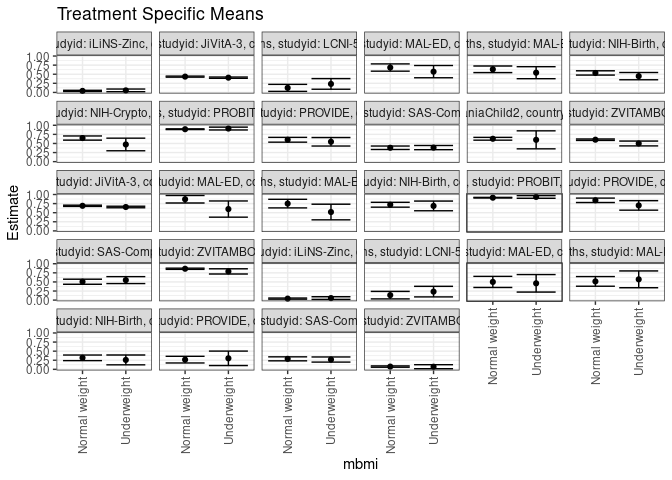

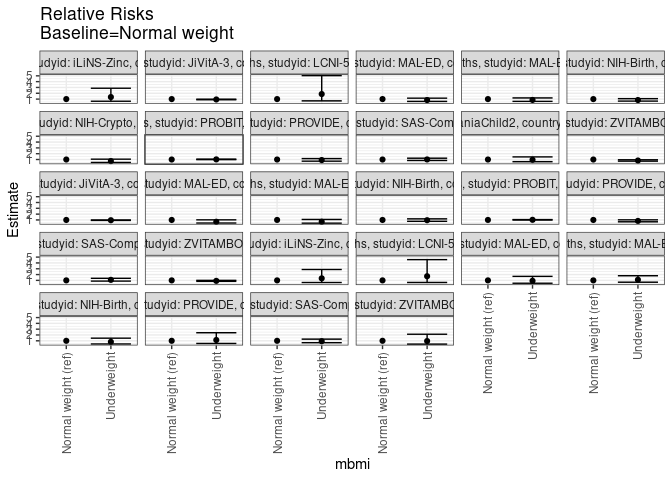

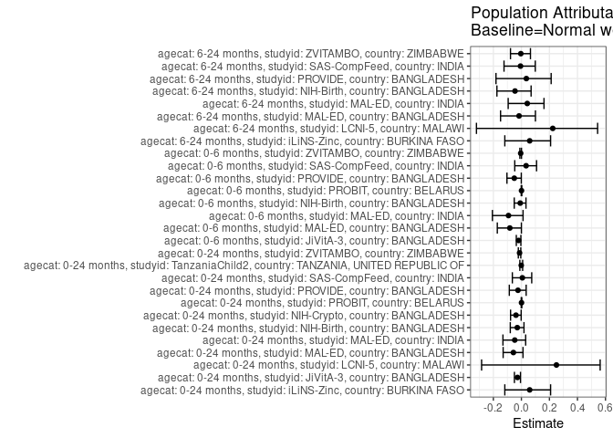

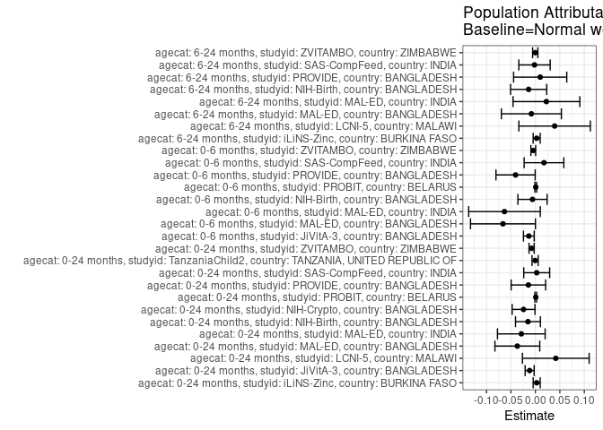

## Results Table

### Parameter: TSM

| agecat | studyid | country | intervention_level | baseline_level | estimate | ci_lower | ci_upper |
| --- | --- | --- | --- | --- | --- | --- | --- |
| 0-24 months | iLiNS-Zinc | BURKINA FASO | Normal weight | NA | 0.0414747 | 0.0260799 | 0.0568695 |
| 0-24 months | iLiNS-Zinc | BURKINA FASO | Underweight | NA | 0.0559441 | 0.0191705 | 0.0927176 |
| 0-24 months | JiVitA-3 | BANGLADESH | Normal weight | NA | 0.4344265 | 0.4198684 | 0.4489846 |
| 0-24 months | JiVitA-3 | BANGLADESH | Underweight | NA | 0.4055729 | 0.3882892 | 0.4228566 |
| 0-24 months | LCNI-5 | MALAWI | Normal weight | NA | 0.1250000 | 0.0290888 | 0.2209112 |
| 0-24 months | LCNI-5 | MALAWI | Underweight | NA | 0.2333333 | 0.0868920 | 0.3797747 |
| 0-24 months | MAL-ED | BANGLADESH | Normal weight | NA | 0.6844434 | 0.5847661 | 0.7841207 |
| 0-24 months | MAL-ED | BANGLADESH | Underweight | NA | 0.5711048 | 0.4022055 | 0.7400041 |
| 0-24 months | MAL-ED | INDIA | Normal weight | NA | 0.6355499 | 0.5447501 | 0.7263497 |
| 0-24 months | MAL-ED | INDIA | Underweight | NA | 0.5424105 | 0.3775946 | 0.7072263 |
| 0-24 months | NIH-Birth | BANGLADESH | Normal weight | NA | 0.5354101 | 0.4767565 | 0.5940636 |
| 0-24 months | NIH-Birth | BANGLADESH | Underweight | NA | 0.4479024 | 0.3482799 | 0.5475250 |
| 0-24 months | NIH-Crypto | BANGLADESH | Normal weight | NA | 0.6487938 | 0.5917607 | 0.7058270 |
| 0-24 months | NIH-Crypto | BANGLADESH | Underweight | NA | 0.4721094 | 0.2986639 | 0.6455550 |
| 0-24 months | PROBIT | BELARUS | Normal weight | NA | 0.8919230 | 0.8820809 | 0.9017651 |
| 0-24 months | PROBIT | BELARUS | Underweight | NA | 0.9098181 | 0.8708320 | 0.9488043 |
| 0-24 months | PROVIDE | BANGLADESH | Normal weight | NA | 0.6017775 | 0.5355587 | 0.6679964 |
| 0-24 months | PROVIDE | BANGLADESH | Underweight | NA | 0.5464011 | 0.4295109 | 0.6632912 |
| 0-24 months | SAS-CompFeed | INDIA | Normal weight | NA | 0.3817192 | 0.3344782 | 0.4289602 |
| 0-24 months | SAS-CompFeed | INDIA | Underweight | NA | 0.3862550 | 0.3289198 | 0.4435903 |
| 0-24 months | TanzaniaChild2 | TANZANIA, UNITED REPUBLIC OF | Normal weight | NA | 0.6288210 | 0.5904220 | 0.6672199 |
| 0-24 months | TanzaniaChild2 | TANZANIA, UNITED REPUBLIC OF | Underweight | NA | 0.6000000 | 0.3523180 | 0.8476820 |
| 0-24 months | ZVITAMBO | ZIMBABWE | Normal weight | NA | 0.6034207 | 0.5841018 | 0.6227397 |
| 0-24 months | ZVITAMBO | ZIMBABWE | Underweight | NA | 0.4994398 | 0.4328889 | 0.5659907 |
| 0-6 months | JiVitA-3 | BANGLADESH | Normal weight | NA | 0.6892674 | 0.6722441 | 0.7062906 |
| 0-6 months | JiVitA-3 | BANGLADESH | Underweight | NA | 0.6562555 | 0.6349047 | 0.6776062 |
| 0-6 months | MAL-ED | BANGLADESH | Normal weight | NA | 0.8695652 | 0.7664853 | 0.9726451 |
| 0-6 months | MAL-ED | BANGLADESH | Underweight | NA | 0.6000000 | 0.3773683 | 0.8226317 |
| 0-6 months | MAL-ED | INDIA | Normal weight | NA | 0.7499307 | 0.6311793 | 0.8686821 |
| 0-6 months | MAL-ED | INDIA | Underweight | NA | 0.5182967 | 0.3031838 | 0.7334095 |
| 0-6 months | NIH-Birth | BANGLADESH | Normal weight | NA | 0.7189126 | 0.6522792 | 0.7855460 |
| 0-6 months | NIH-Birth | BANGLADESH | Underweight | NA | 0.6860876 | 0.5525948 | 0.8195804 |
| 0-6 months | PROBIT | BELARUS | Normal weight | NA | 0.9125250 | 0.9032690 | 0.9217809 |
| 0-6 months | PROBIT | BELARUS | Underweight | NA | 0.9331398 | 0.8965810 | 0.9696987 |
| 0-6 months | PROVIDE | BANGLADESH | Normal weight | NA | 0.8405124 | 0.7794053 | 0.9016194 |
| 0-6 months | PROVIDE | BANGLADESH | Underweight | NA | 0.6997021 | 0.5688887 | 0.8305154 |
| 0-6 months | SAS-CompFeed | INDIA | Normal weight | NA | 0.5053189 | 0.4354463 | 0.5751915 |
| 0-6 months | SAS-CompFeed | INDIA | Underweight | NA | 0.5499152 | 0.4549084 | 0.6449221 |
| 0-6 months | ZVITAMBO | ZIMBABWE | Normal weight | NA | 0.8624465 | 0.8459826 | 0.8789104 |
| 0-6 months | ZVITAMBO | ZIMBABWE | Underweight | NA | 0.7893274 | 0.7178402 | 0.8608146 |
| 6-24 months | iLiNS-Zinc | BURKINA FASO | Normal weight | NA | 0.0414747 | 0.0260799 | 0.0568695 |
| 6-24 months | iLiNS-Zinc | BURKINA FASO | Underweight | NA | 0.0559441 | 0.0191705 | 0.0927176 |
| 6-24 months | LCNI-5 | MALAWI | Normal weight | NA | 0.1363636 | 0.0329768 | 0.2397505 |
| 6-24 months | LCNI-5 | MALAWI | Underweight | NA | 0.2333333 | 0.0877343 | 0.3789324 |
| 6-24 months | MAL-ED | BANGLADESH | Normal weight | NA | 0.5000000 | 0.3474407 | 0.6525593 |
| 6-24 months | MAL-ED | BANGLADESH | Underweight | NA | 0.4615385 | 0.2210093 | 0.7020676 |
| 6-24 months | MAL-ED | INDIA | Normal weight | NA | 0.5143255 | 0.3809385 | 0.6477125 |
| 6-24 months | MAL-ED | INDIA | Underweight | NA | 0.5713530 | 0.3406077 | 0.8020982 |
| 6-24 months | NIH-Birth | BANGLADESH | Normal weight | NA | 0.3168449 | 0.2398749 | 0.3938149 |
| 6-24 months | NIH-Birth | BANGLADESH | Underweight | NA | 0.2592075 | 0.1241322 | 0.3942829 |
| 6-24 months | PROVIDE | BANGLADESH | Normal weight | NA | 0.2666398 | 0.1747311 | 0.3585485 |
| 6-24 months | PROVIDE | BANGLADESH | Underweight | NA | 0.3033335 | 0.1048169 | 0.5018501 |
| 6-24 months | SAS-CompFeed | INDIA | Normal weight | NA | 0.2894924 | 0.2344510 | 0.3445339 |
| 6-24 months | SAS-CompFeed | INDIA | Underweight | NA | 0.2695603 | 0.1987316 | 0.3403891 |
| 6-24 months | ZVITAMBO | ZIMBABWE | Normal weight | NA | 0.0756098 | 0.0575698 | 0.0936498 |
| 6-24 months | ZVITAMBO | ZIMBABWE | Underweight | NA | 0.0722892 | 0.0168678 | 0.1277105 |

### Parameter: E(Y)

| agecat | studyid | country | intervention_level | baseline_level | estimate | ci_lower | ci_upper |
| --- | --- | --- | --- | --- | --- | --- | --- |
| 0-24 months | iLiNS-Zinc | BURKINA FASO | NA | NA | 0.0440806 | 0.0298222 | 0.0583390 |
| 0-24 months | JiVitA-3 | BANGLADESH | NA | NA | 0.4226585 | 0.4115120 | 0.4338051 |
| 0-24 months | LCNI-5 | MALAWI | NA | NA | 0.1666667 | 0.0842830 | 0.2490503 |
| 0-24 months | MAL-ED | BANGLADESH | NA | NA | 0.6475410 | 0.5613826 | 0.7336993 |
| 0-24 months | MAL-ED | INDIA | NA | NA | 0.6067416 | 0.5268346 | 0.6866486 |
| 0-24 months | NIH-Birth | BANGLADESH | NA | NA | 0.5201900 | 0.4695846 | 0.5707955 |
| 0-24 months | NIH-Crypto | BANGLADESH | NA | NA | 0.6245955 | 0.5705077 | 0.6786833 |
| 0-24 months | PROBIT | BELARUS | NA | NA | 0.8926668 | 0.8831189 | 0.9022148 |
| 0-24 months | PROVIDE | BANGLADESH | NA | NA | 0.5874587 | 0.5306185 | 0.6442990 |
| 0-24 months | SAS-CompFeed | INDIA | NA | NA | 0.3844086 | 0.3477135 | 0.4211037 |
| 0-24 months | TanzaniaChild2 | TANZANIA, UNITED REPUBLIC OF | NA | NA | 0.6282051 | 0.5902579 | 0.6661523 |
| 0-24 months | ZVITAMBO | ZIMBABWE | NA | NA | 0.5956183 | 0.5770555 | 0.6141810 |
| 0-6 months | JiVitA-3 | BANGLADESH | NA | NA | 0.6758591 | 0.6624976 | 0.6892206 |
| 0-6 months | MAL-ED | BANGLADESH | NA | NA | 0.8032787 | 0.7044023 | 0.9021551 |
| 0-6 months | MAL-ED | INDIA | NA | NA | 0.6867470 | 0.5837430 | 0.7897510 |
| 0-6 months | NIH-Birth | BANGLADESH | NA | NA | 0.7130045 | 0.6535890 | 0.7724200 |
| 0-6 months | PROBIT | BELARUS | NA | NA | 0.9132600 | 0.9042761 | 0.9222438 |
| 0-6 months | PROVIDE | BANGLADESH | NA | NA | 0.8000000 | 0.7425836 | 0.8574164 |
| 0-6 months | SAS-CompFeed | INDIA | NA | NA | 0.5228758 | 0.4664267 | 0.5793250 |
| 0-6 months | ZVITAMBO | ZIMBABWE | NA | NA | 0.8581006 | 0.8420009 | 0.8742002 |
| 6-24 months | iLiNS-Zinc | BURKINA FASO | NA | NA | 0.0440806 | 0.0298222 | 0.0583390 |
| 6-24 months | LCNI-5 | MALAWI | NA | NA | 0.1756757 | 0.0897916 | 0.2615597 |
| 6-24 months | MAL-ED | BANGLADESH | NA | NA | 0.4918033 | 0.3610932 | 0.6225134 |
| 6-24 months | MAL-ED | INDIA | NA | NA | 0.5368421 | 0.4223932 | 0.6512910 |
| 6-24 months | NIH-Birth | BANGLADESH | NA | NA | 0.3030303 | 0.2377927 | 0.3682679 |
| 6-24 months | PROVIDE | BANGLADESH | NA | NA | 0.2764228 | 0.1950773 | 0.3577682 |
| 6-24 months | SAS-CompFeed | INDIA | NA | NA | 0.2876712 | 0.2441703 | 0.3311721 |
| 6-24 months | ZVITAMBO | ZIMBABWE | NA | NA | 0.0753045 | 0.0581490 | 0.0924601 |

### Parameter: RR

| agecat | studyid | country | intervention_level | baseline_level | estimate | ci_lower | ci_upper |
| --- | --- | --- | --- | --- | --- | --- | --- |
| 0-24 months | iLiNS-Zinc | BURKINA FASO | Normal weight | Normal weight | 1.0000000 | 1.0000000 | 1.0000000 |
| 0-24 months | iLiNS-Zinc | BURKINA FASO | Underweight | Normal weight | 1.3488733 | 0.6340510 | 2.8695789 |
| 0-24 months | JiVitA-3 | BANGLADESH | Normal weight | Normal weight | 1.0000000 | 1.0000000 | 1.0000000 |
| 0-24 months | JiVitA-3 | BANGLADESH | Underweight | Normal weight | 0.9335822 | 0.8843836 | 0.9855178 |
| 0-24 months | LCNI-5 | MALAWI | Normal weight | Normal weight | 1.0000000 | 1.0000000 | 1.0000000 |
| 0-24 months | LCNI-5 | MALAWI | Underweight | Normal weight | 1.8666667 | 0.6926702 | 5.0304525 |
| 0-24 months | MAL-ED | BANGLADESH | Normal weight | Normal weight | 1.0000000 | 1.0000000 | 1.0000000 |
| 0-24 months | MAL-ED | BANGLADESH | Underweight | Normal weight | 0.8344077 | 0.5996053 | 1.1611574 |
| 0-24 months | MAL-ED | INDIA | Normal weight | Normal weight | 1.0000000 | 1.0000000 | 1.0000000 |
| 0-24 months | MAL-ED | INDIA | Underweight | Normal weight | 0.8534506 | 0.6077451 | 1.1984926 |
| 0-24 months | NIH-Birth | BANGLADESH | Normal weight | Normal weight | 1.0000000 | 1.0000000 | 1.0000000 |
| 0-24 months | NIH-Birth | BANGLADESH | Underweight | Normal weight | 0.8365596 | 0.6527747 | 1.0720881 |
| 0-24 months | NIH-Crypto | BANGLADESH | Normal weight | Normal weight | 1.0000000 | 1.0000000 | 1.0000000 |
| 0-24 months | NIH-Crypto | BANGLADESH | Underweight | Normal weight | 0.7276725 | 0.4984072 | 1.0623989 |
| 0-24 months | PROBIT | BELARUS | Normal weight | Normal weight | 1.0000000 | 1.0000000 | 1.0000000 |
| 0-24 months | PROBIT | BELARUS | Underweight | Normal weight | 1.0200635 | 0.9759102 | 1.0662145 |
| 0-24 months | PROVIDE | BANGLADESH | Normal weight | Normal weight | 1.0000000 | 1.0000000 | 1.0000000 |
| 0-24 months | PROVIDE | BANGLADESH | Underweight | Normal weight | 0.9079785 | 0.7133283 | 1.1557441 |
| 0-24 months | SAS-CompFeed | INDIA | Normal weight | Normal weight | 1.0000000 | 1.0000000 | 1.0000000 |
| 0-24 months | SAS-CompFeed | INDIA | Underweight | Normal weight | 1.0118827 | 0.8350814 | 1.2261159 |
| 0-24 months | TanzaniaChild2 | TANZANIA, UNITED REPUBLIC OF | Normal weight | Normal weight | 1.0000000 | 1.0000000 | 1.0000000 |
| 0-24 months | TanzaniaChild2 | TANZANIA, UNITED REPUBLIC OF | Underweight | Normal weight | 0.9541667 | 0.6286319 | 1.4482784 |
| 0-24 months | ZVITAMBO | ZIMBABWE | Normal weight | Normal weight | 1.0000000 | 1.0000000 | 1.0000000 |
| 0-24 months | ZVITAMBO | ZIMBABWE | Underweight | Normal weight | 0.8276809 | 0.7216450 | 0.9492973 |
| 0-6 months | JiVitA-3 | BANGLADESH | Normal weight | Normal weight | 1.0000000 | 1.0000000 | 1.0000000 |
| 0-6 months | JiVitA-3 | BANGLADESH | Underweight | Normal weight | 0.9521058 | 0.9141007 | 0.9916910 |
| 0-6 months | MAL-ED | BANGLADESH | Normal weight | Normal weight | 1.0000000 | 1.0000000 | 1.0000000 |
| 0-6 months | MAL-ED | BANGLADESH | Underweight | Normal weight | 0.6900000 | 0.4673961 | 1.0186222 |
| 0-6 months | MAL-ED | INDIA | Normal weight | Normal weight | 1.0000000 | 1.0000000 | 1.0000000 |
| 0-6 months | MAL-ED | INDIA | Underweight | Normal weight | 0.6911261 | 0.4422388 | 1.0800845 |
| 0-6 months | NIH-Birth | BANGLADESH | Normal weight | Normal weight | 1.0000000 | 1.0000000 | 1.0000000 |
| 0-6 months | NIH-Birth | BANGLADESH | Underweight | Normal weight | 0.9543408 | 0.7693065 | 1.1838797 |
| 0-6 months | PROBIT | BELARUS | Normal weight | Normal weight | 1.0000000 | 1.0000000 | 1.0000000 |
| 0-6 months | PROBIT | BELARUS | Underweight | Normal weight | 1.0225910 | 0.9820277 | 1.0648298 |
| 0-6 months | PROVIDE | BANGLADESH | Normal weight | Normal weight | 1.0000000 | 1.0000000 | 1.0000000 |
| 0-6 months | PROVIDE | BANGLADESH | Underweight | Normal weight | 0.8324709 | 0.6809978 | 1.0176358 |
| 0-6 months | SAS-CompFeed | INDIA | Normal weight | Normal weight | 1.0000000 | 1.0000000 | 1.0000000 |
| 0-6 months | SAS-CompFeed | INDIA | Underweight | Normal weight | 1.0882538 | 0.8737879 | 1.3553590 |
| 0-6 months | ZVITAMBO | ZIMBABWE | Normal weight | Normal weight | 1.0000000 | 1.0000000 | 1.0000000 |
| 0-6 months | ZVITAMBO | ZIMBABWE | Underweight | Normal weight | 0.9152190 | 0.8343410 | 1.0039369 |
| 6-24 months | iLiNS-Zinc | BURKINA FASO | Normal weight | Normal weight | 1.0000000 | 1.0000000 | 1.0000000 |
| 6-24 months | iLiNS-Zinc | BURKINA FASO | Underweight | Normal weight | 1.3488733 | 0.6340510 | 2.8695789 |
| 6-24 months | LCNI-5 | MALAWI | Normal weight | Normal weight | 1.0000000 | 1.0000000 | 1.0000000 |
| 6-24 months | LCNI-5 | MALAWI | Underweight | Normal weight | 1.7111111 | 0.6408783 | 4.5685760 |
| 6-24 months | MAL-ED | BANGLADESH | Normal weight | Normal weight | 1.0000000 | 1.0000000 | 1.0000000 |
| 6-24 months | MAL-ED | BANGLADESH | Underweight | Normal weight | 0.9230769 | 0.5044974 | 1.6889501 |
| 6-24 months | MAL-ED | INDIA | Normal weight | Normal weight | 1.0000000 | 1.0000000 | 1.0000000 |
| 6-24 months | MAL-ED | INDIA | Underweight | Normal weight | 1.1108781 | 0.6862777 | 1.7981789 |
| 6-24 months | NIH-Birth | BANGLADESH | Normal weight | Normal weight | 1.0000000 | 1.0000000 | 1.0000000 |
| 6-24 months | NIH-Birth | BANGLADESH | Underweight | Normal weight | 0.8180898 | 0.4594733 | 1.4566044 |
| 6-24 months | PROVIDE | BANGLADESH | Normal weight | Normal weight | 1.0000000 | 1.0000000 | 1.0000000 |
| 6-24 months | PROVIDE | BANGLADESH | Underweight | Normal weight | 1.1376154 | 0.5415199 | 2.3898819 |
| 6-24 months | SAS-CompFeed | INDIA | Normal weight | Normal weight | 1.0000000 | 1.0000000 | 1.0000000 |
| 6-24 months | SAS-CompFeed | INDIA | Underweight | Normal weight | 0.9311480 | 0.6733597 | 1.2876277 |
| 6-24 months | ZVITAMBO | ZIMBABWE | Normal weight | Normal weight | 1.0000000 | 1.0000000 | 1.0000000 |
| 6-24 months | ZVITAMBO | ZIMBABWE | Underweight | Normal weight | 0.9560824 | 0.4283383 | 2.1340459 |

### Parameter: PAR

| agecat | studyid | country | intervention_level | baseline_level | estimate | ci_lower | ci_upper |
| --- | --- | --- | --- | --- | --- | --- | --- |
| 0-24 months | iLiNS-Zinc | BURKINA FASO | Normal weight | NA | 0.0026060 | -0.0045811 | 0.0097930 |
| 0-24 months | JiVitA-3 | BANGLADESH | Normal weight | NA | -0.0117680 | -0.0209296 | -0.0026064 |
| 0-24 months | LCNI-5 | MALAWI | Normal weight | NA | 0.0416667 | -0.0265326 | 0.1098659 |
| 0-24 months | MAL-ED | BANGLADESH | Normal weight | NA | -0.0369024 | -0.0827140 | 0.0089092 |
| 0-24 months | MAL-ED | INDIA | Normal weight | NA | -0.0288083 | -0.0775314 | 0.0199148 |
| 0-24 months | NIH-Birth | BANGLADESH | Normal weight | NA | -0.0152200 | -0.0406957 | 0.0102556 |
| 0-24 months | NIH-Crypto | BANGLADESH | Normal weight | NA | -0.0241984 | -0.0475448 | -0.0008520 |
| 0-24 months | PROBIT | BELARUS | Normal weight | NA | 0.0007438 | -0.0011255 | 0.0026132 |
| 0-24 months | PROVIDE | BANGLADESH | Normal weight | NA | -0.0143188 | -0.0495461 | 0.0209085 |
| 0-24 months | SAS-CompFeed | INDIA | Normal weight | NA | 0.0026894 | -0.0238363 | 0.0292152 |
| 0-24 months | TanzaniaChild2 | TANZANIA, UNITED REPUBLIC OF | Normal weight | NA | -0.0006158 | -0.0068812 | 0.0056495 |
| 0-24 months | ZVITAMBO | ZIMBABWE | Normal weight | NA | -0.0078025 | -0.0130095 | -0.0025954 |
| 0-6 months | JiVitA-3 | BANGLADESH | Normal weight | NA | -0.0134082 | -0.0243756 | -0.0024409 |
| 0-6 months | MAL-ED | BANGLADESH | Normal weight | NA | -0.0662865 | -0.1326161 | 0.0000431 |
| 0-6 months | MAL-ED | INDIA | Normal weight | NA | -0.0631837 | -0.1363682 | 0.0100008 |
| 0-6 months | NIH-Birth | BANGLADESH | Normal weight | NA | -0.0059081 | -0.0357482 | 0.0239320 |
| 0-6 months | PROBIT | BELARUS | Normal weight | NA | 0.0007350 | -0.0010764 | 0.0025463 |
| 0-6 months | PROVIDE | BANGLADESH | Normal weight | NA | -0.0405124 | -0.0806094 | -0.0004154 |
| 0-6 months | SAS-CompFeed | INDIA | Normal weight | NA | 0.0175569 | -0.0230010 | 0.0581148 |
| 0-6 months | ZVITAMBO | ZIMBABWE | Normal weight | NA | -0.0043460 | -0.0092362 | 0.0005443 |
| 6-24 months | iLiNS-Zinc | BURKINA FASO | Normal weight | NA | 0.0026060 | -0.0045811 | 0.0097930 |
| 6-24 months | LCNI-5 | MALAWI | Normal weight | NA | 0.0393120 | -0.0337215 | 0.1123456 |
| 6-24 months | MAL-ED | BANGLADESH | Normal weight | NA | -0.0081967 | -0.0695069 | 0.0531135 |
| 6-24 months | MAL-ED | INDIA | Normal weight | NA | 0.0225166 | -0.0456884 | 0.0907216 |
| 6-24 months | NIH-Birth | BANGLADESH | Normal weight | NA | -0.0138146 | -0.0507577 | 0.0231286 |
| 6-24 months | PROVIDE | BANGLADESH | Normal weight | NA | 0.0097830 | -0.0445299 | 0.0640959 |
| 6-24 months | SAS-CompFeed | INDIA | Normal weight | NA | -0.0018212 | -0.0338376 | 0.0301952 |
| 6-24 months | ZVITAMBO | ZIMBABWE | Normal weight | NA | -0.0003052 | -0.0056628 | 0.0050524 |

### Parameter: PAF

| agecat | studyid | country | intervention_level | baseline_level | estimate | ci_lower | ci_upper |
| --- | --- | --- | --- | --- | --- | --- | --- |
| 0-24 months | iLiNS-Zinc | BURKINA FASO | Normal weight | NA | 0.0591178 | -0.1182440 | 0.2083487 |
| 0-24 months | JiVitA-3 | BANGLADESH | Normal weight | NA | -0.0278428 | -0.0497481 | -0.0063946 |
| 0-24 months | LCNI-5 | MALAWI | Normal weight | NA | 0.2500000 | -0.2838955 | 0.5618802 |
| 0-24 months | MAL-ED | BANGLADESH | Normal weight | NA | -0.0569885 | -0.1301666 | 0.0114513 |
| 0-24 months | MAL-ED | INDIA | Normal weight | NA | -0.0474804 | -0.1316479 | 0.0304271 |
| 0-24 months | NIH-Birth | BANGLADESH | Normal weight | NA | -0.0292586 | -0.0792360 | 0.0184045 |
| 0-24 months | NIH-Crypto | BANGLADESH | Normal weight | NA | -0.0387425 | -0.0772550 | -0.0016068 |
| 0-24 months | PROBIT | BELARUS | Normal weight | NA | 0.0008333 | -0.0012636 | 0.0029257 |
| 0-24 months | PROVIDE | BANGLADESH | Normal weight | NA | -0.0243741 | -0.0862330 | 0.0339620 |
| 0-24 months | SAS-CompFeed | INDIA | Normal weight | NA | 0.0069962 | -0.0645321 | 0.0737184 |
| 0-24 months | TanzaniaChild2 | TANZANIA, UNITED REPUBLIC OF | Normal weight | NA | -0.0009803 | -0.0110044 | 0.0089444 |
| 0-24 months | ZVITAMBO | ZIMBABWE | Normal weight | NA | -0.0130998 | -0.0218862 | -0.0043889 |
| 0-6 months | JiVitA-3 | BANGLADESH | Normal weight | NA | -0.0198388 | -0.0362129 | -0.0037234 |
| 0-6 months | MAL-ED | BANGLADESH | Normal weight | NA | -0.0825200 | -0.1719002 | 0.0000433 |
| 0-6 months | MAL-ED | INDIA | Normal weight | NA | -0.0920043 | -0.2067796 | 0.0118548 |
| 0-6 months | NIH-Birth | BANGLADESH | Normal weight | NA | -0.0082862 | -0.0510201 | 0.0327102 |
| 0-6 months | PROBIT | BELARUS | Normal weight | NA | 0.0008048 | -0.0011810 | 0.0027866 |
| 0-6 months | PROVIDE | BANGLADESH | Normal weight | NA | -0.0506405 | -0.1030728 | -0.0007004 |
| 0-6 months | SAS-CompFeed | INDIA | Normal weight | NA | 0.0335775 | -0.0473224 | 0.1082284 |
| 0-6 months | ZVITAMBO | ZIMBABWE | Normal weight | NA | -0.0050646 | -0.0107879 | 0.0006262 |
| 6-24 months | iLiNS-Zinc | BURKINA FASO | Normal weight | NA | 0.0591178 | -0.1182440 | 0.2083487 |
| 6-24 months | LCNI-5 | MALAWI | Normal weight | NA | 0.2237762 | -0.3205992 | 0.5437500 |
| 6-24 months | MAL-ED | BANGLADESH | Normal weight | NA | -0.0166667 | -0.1486245 | 0.1001314 |
| 6-24 months | MAL-ED | INDIA | Normal weight | NA | 0.0419427 | -0.0943009 | 0.1612235 |
| 6-24 months | NIH-Birth | BANGLADESH | Normal weight | NA | -0.0455880 | -0.1746412 | 0.0692866 |
| 6-24 months | PROVIDE | BANGLADESH | Normal weight | NA | 0.0353914 | -0.1812534 | 0.2123030 |
| 6-24 months | SAS-CompFeed | INDIA | Normal weight | NA | -0.0063309 | -0.1239751 | 0.0989998 |
| 6-24 months | ZVITAMBO | ZIMBABWE | Normal weight | NA | -0.0040531 | -0.0777733 | 0.0646246 |